# Research Proposal

## Pavan Chaggar

### DPhil Student Mathematical Institute University of Oxford

# Outline

- Background
- Summary of Rotation Work
- Intended Future Work

# Background

## Alzheimer's Disease

Alzheimer's Disease (AD) is a neurological disorder characterised by progressive structural brain damage and cognitive decline. Toxic forms of two proteins are thought to underly the progression of AD: Amyloid-$\beta$ and $\tau$-protein.

Evidence suggest these proteins exhibit prion-like properties, namely their ability to induce misfolding in their surrounding counterparts. This property begets the ability of toxic A$\beta$ and $\tau$P to propogate through the brain.

Additionally, A$\beta$ and $\tau$P have been shown to have a characteristic spread through the brain. $\tau$P, in particular, is correlated with progression of atrophy in the brain.

These predictable properties show potential to be used as a clinilcal biomarker for the progression of AD.

[figure not shown]

## Mathematical Modelling

Increasingly sophisticated mathematical models have captured toxic protein diffusion through the brain. These are typically of two flavours: ODE models or probabilistic models.

Some modelling work has provided correlative analyses between simulated protein spread, atrophy from sMRI [1] and patient PET [2]. However, these models are either simple linear ODE models or probabilstic models that do not provide mechanistic insights.

Augmented model such as FKPP equation or heterodimer models offer a richer explanation of how dynamics between prion-like proteins *causes* AD pathology. However, with growing model complexity, rigourous comparison with data becomes more difficult.

Models of toxic protein propogation focus on (reaction-)diffusion ordinary differential equation models. The simplest of which is the network diffusion equation, considered first in Raj et al., 2015:

$$ \frac{d\mathbf{p}}{dt} = -k\mathcal{L}\mathbf{p} $$

This only descibes diffusion on a network. To include some description of prion-like dynamics, we can augment the heat equation with a logsitic growth term (Fornari, Goriely, et al. 2018):

$$ \frac{d\mathbf{p}_{i}}{dt} = -k\sum_{j=1}^{N}\mathcal{L}_{ij} \mathbf{p}_j + \alpha \mathbf{p}_i(1 - \mathbf{p}_i) $$

and we can add additional complexity with a couple chemical reaction network with interaction between healthy and and toxic proteins (Fornari, Goriely, et al. 2018).

\begin{align} \frac{d\mathbf{p}_{i}}{dt} & = -\rho\sum\limits_{j=1}^{N}\mathcal{L}_{ij}\mathbf{p}_j + k_0 - k_1 \mathbf{p}_i - k_{12}\mathbf{p}_i \mathbf{\hat{p}}_i, \\ \frac{d\mathbf{\hat{p}}_i}{dt} &= -\hat{\rho}\sum\limits_{j=1}^{N}\mathcal{L}_{ij}\mathbf{\hat{p}}_j - \hat{k}_1 \mathbf{\hat{p}}_i + k_{12}\mathbf{p_i}\mathbf{\hat{p}_i} \end{align}

and multiple protein species (Thompson, Goriely et al. 2020):

\begin{align} \frac{d\mathbf{v}_i}{dt} & = -\kappa\sum\limits_{j=1}^{N}\mathcal{L}_{ij}\mathbf{v}_j + b_0 - b_1 \mathbf{v}_i - b_{12}v_i \mathbf{\hat{v}}_i -b_3\mathbf{\hat{p}}_i\mathbf{v}_i\mathbf{\hat{v}}_i, \\ \frac{d\mathbf{\hat{v}}_i}{dt} &= -\hat{\kappa}\sum\limits_{j=1}^{N}\mathcal{L}_{ij}\mathbf{\hat{v}}_j - \hat{b}_1 \mathbf{\hat{v}}_i + b_{12}\mathbf{v}_i\mathbf{\hat{v}}_i + b_3\mathbf{\hat{p}}_i\mathbf{v}_i\mathbf{\hat{v}}_i, \end{align}

**Left**: FKPP simulation **Right**: Heterodimer Simulation

[figure not shown]

# Summary of Rotation Work

The first task was to determine how best to compare models against data. To this end, I conducted a pilot analysis on ADNI subjects who had structural MRI, A$\beta$ and $\tau$P PET images.

Using a standard data processing pipeline in SPM, I analysed the sMRI and PET data for the four groups: young cognitively normal (sMRI only), old cognitively normal, late MCI, early AD.

The results of these analyses were summarised on a connectome to facilitate comparison with connectome network simulations.

##### Atrophy and Diffusion Maps on the Connectome

[figure not shown]

## Inference

Now that we have models and data, we need a method to bring them together. Where as previous studies have opted for correlative analysis, we aim to fit a full generative model of the data and model within a Bayesian framework.

This will allow us to obtain data-derived parameter estimates and gain insight into model uncertainty and identifiability.

We initially test this using variational Bayesian analysis.

[figure not shown]

# Future Work

## Year One

A number of issues were uncovered during my rotation work. Addressing these will be the basis of my initial work.

#### Have control over connectome generating process

There is a mismatch between connectomes currently used in the research group and those that can be used for image analysis.

Simulations on connectomes of different resolutions give different qualitative results.

The connectome is an important part of simulations and is highly correlated with other model parameters. Having control of this and understanding its modelling properties will enhance reproducibility.

#### Continue to build and test software for Bayesian inference on brain network models.

AVB implementation is presently unstable and is potentially too restrictive for the mechanistic models.

Other inference schemes such as automatic differentation variational inference or likelihood-free based inference will be explored as they offer greater flexibility for generative modelling.

These should be packages and tested on small network models that be assess with MCMC.

#### Work on first paper(!)

This will likely focus on modelling atrophy measures based on structural MRI scans

The paper should, in part, demonstate the use of the software.

## Year Two/Three

Work during years two and three will focus on continued development of the network inference software and using it for hypothesis testing.

#### Software Development

- Make an easy interface for users to implement robust simulations of arbitrary network models.
- Develop an inference machinary to combine information from multiple scales.
- Write software paper and release package.

#### Model Development

- Work on generative models that incorporate multiple forms of data, starting with PET tracer images. Others modalities include fMRI, diffusion imaging and/or glymphatic clearance data.
- Hypothesis testing using mechanistic modfels and Bayesian inference.
- Write paper on multiscale multimodal inference of AD pathology.

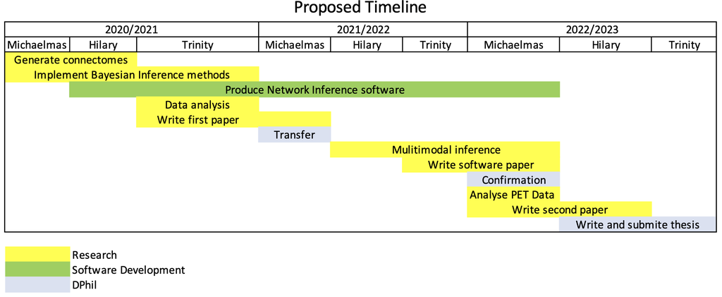

### References:

[1]: Raj A, LoCastro E, Kuceyeski A, Tosun D, Relkin N, Weiner M, ADNI, et al. Network diffusion model of progression predicts longitudinal patterns of atrophy and metabolism in Alzheimer’s disease. Cell reports. 2015; 10(3):359–369.

[2] Jacob W Vogel, Yasser Iturria-Medina, Olof T Strandberg, Ruben Smith, Elizabeth Levitis, Alan C Evans, and Oskar Hansson. Spread of patho- logical tau proteins through communicating neurons in human alzheimer’s disease. Nature Communications, 11(1):1–15, 2020.

[3]: Fornari S, Schäfer A, Jucker M, Goriely A, Kuhl E. Prion-like spreading of Alzheimer’s disease within the brain’s connectome. Journal of the Royal Society Interface. 2019; 16(159):20190356

Walker, L.C., Jucker, M.: Neurodegenerative diseases: expanding the prion concept.Annual review of neuroscience38, 87–103 (2015

H Matusda. Voxel-based Morphometry of Brain MRI in Normal Aging and Alzheimer’s Disease, Aging Dis. 2013 Feb; 4(1): 29–37